# Lab 1 - Regressione Lineare in R

Ilaria Prosdocimi

```r
getwd()
```

```
## [1] "C:/Users/TOMFAC01/Documents/Tommaso/Analisi predittiva/labs/Lab 01-20251204"
```

In questo lab useremo il file che contiene informazioni sui pinguini delle isole Palmers:

```r
pengs <- read.csv("../data/penguins.csv")
summary(pengs)
```

```
##    species             island          bill_length_mm  bill_depth_mm
##  Length:344         Length:344         Min.   :32.10   Min.   :13.10
##  Class :character   Class :character   1st Qu.:39.23   1st Qu.:15.60
##  Mode  :character   Mode  :character   Median :44.45   Median :17.30
##                                        Mean   :43.92   Mean   :17.15
##                                        3rd Qu.:48.50   3rd Qu.:18.70
##                                        Max.   :59.60   Max.   :21.50
##                                        NA's   :2       NA's   :2
##  flipper_length_mm  body_mass_g       sex                 year
##  Min.   :172.0     Min.   :2700   Length:344         Min.   :2007
##  1st Qu.:190.0     1st Qu.:3550   Class :character   1st Qu.:2007
##  Median :197.0     Median :4050   Mode  :character   Median :2008
##  Mean   :200.9     Mean   :4202                      Mean   :2008
##  3rd Qu.:213.0     3rd Qu.:4750                      3rd Qu.:2009
##  Max.   :231.0     Max.   :6300                      Max.   :2009
##  NA's   :2         NA's   :2
```

```r
## eliminiamo le righe con valori mancanti (non è sempre una buona idea)
pengs <- na.omit(pengs)
nrow(pengs)
```

```
## [1] 333
```

Il primo modello in esame prevede di stimare come la lunghezza della pinna di un pinguino (`flipper_length_mm`) varia in funzione della massa (`body_mass_g`).

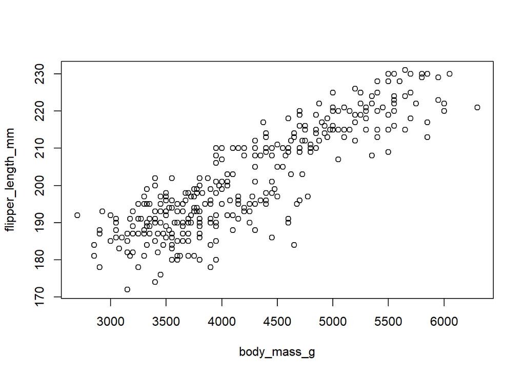

```r
plot(pengs[,c("body_mass_g","flipper_length_mm")])
```

Possiamo usare gli stimatori plug-in ed ottenere:

$$\hat{\beta}_1 = \frac{c_{XY}}{s^2_{X}}
= r_{XY} \frac{s_{Y}}{s_{X}},\quad \mbox{and} \quad \hat{\beta}_0 =
\overline{y}-\hat{\beta}_1 \overline{x}$$

```r
rxy <- cor(pengs$flipper_length_mm, pengs$body_mass_g)
sx <- sd(pengs$body_mass_g); sy <- sd(pengs$flipper_length_mm)
mx <- mean(pengs$body_mass_g)
my <- mean(pengs$flipper_length_mm)
beta1_hat <- rxy*sy/sx
beta0_hat <- my - beta1_hat * mx
c(beta0_hat, beta1_hat)
```

```
## [1] 137.03962089   0.01519526
```

Oppure, più realisticamente possiamo usare le funzioni già presenti in R.

# 1 Modelli lineari in R

La principale funzione da usare per stimare modelli lineari in R è `lm` - (si veda `help(lm)`).

Il primo argomento di `lm` è `formula`: con questo argomento si specifica a sinistra di una tilde quale è la variabile risposta e a destra della tilde quale sia il predittore del modello (o i predittori):

```r
fit <- lm(flipper_length_mm~body_mass_g, data = pengs)
```

Possiamo a questo punto *stampare* `fit` per avere informazioni di base:

```r
fit ## in R this corresponds to print(fit)
```

```
##
## Call:
## lm(formula = flipper_length_mm ~ body_mass_g, data = pengs)
##
## Coefficients:
## (Intercept)  body_mass_g
##    137.0396       0.0152
```

La stampa mostra i valori dei coefficienti di un modello lineare semplice: questi sono i valori stimati tramite least square. Possiamo ottenere i valori dei parametri anche con

```r
coef(fit)
```

```
##  (Intercept)  body_mass_g
## 137.03962089   0.01519526
```

Vi sono infatti una serie di funzioni che possiamo applicare all’oggetto `fit` che ha classe `lm`:

```r
class(fit)
```

```
## [1] "lm"
```

Tra le funzioni più utili ci sono per esempio `fitted`, che deriva i valori stimati per le $y_i$ (quindi valuta la funzione $\beta_0 + \beta_1 x_i$ prendendo le stime dei minimi quadrati per $\beta_0$ e $\beta_1$):

```r
head(coef(fit)[1]+coef(fit)[2]*pengs$body_mass_g)
```

```
## [1] 194.0219 194.7816 186.4242 189.4633 192.5023 192.1225
```

```r
head(fitted(fit))
```

```
##        1        2        3        5        6        7
## 194.0219 194.7816 186.4242 189.4633 192.5023 192.1225
```

Vedremo poi che una funzione molto utile è `summary`

```r
summary(fit)
```

```
##
## Call:
## lm(formula = flipper_length_mm ~ body_mass_g, data = pengs)
##
## Residuals:
##     Min      1Q  Median      3Q     Max
## -23.698  -4.983   1.056   5.101  13.933
##
## Coefficients:
##              Estimate Std. Error t value Pr(>|t|)
## (Intercept) 1.370e+02  1.999e+00   68.56   <2e-16 ***
## body_mass_g 1.520e-02  4.667e-04   32.56   <2e-16 ***
## ---
## Signif. codes:  0 '***' 0.001 '**' 0.01 '*' 0.05 '.' 0.1 ' ' 1
##
## Residual standard error: 6.847 on 331 degrees of freedom
## Multiple R-squared:  0.7621, Adjusted R-squared:  0.7614
## F-statistic:  1060 on 1 and 331 DF,  p-value: < 2.2e-16
```

che stampa molte informazioni: discuteremo nel corso le varie parti dell’output.

Notiamo che è presente il valore stimato di $\sigma^2$, la varianza della variabile casuale che descrive l’errore del modello ($\varepsilon$):

$$s_e^2 = \frac{1}{n-2}\sum_{i=1}^{n} (y_i
- \hat{y}_i)^2$$

```r
summary(fit)$sigma
```

```
## [1] 6.84662
```

```r
sqrt(sum((pengs$flipper_length_mm  - fitted(fit))^2)/(nrow(pengs)-2))
```

```
## [1] 6.84662
```

La stima di $\sigma$ viene usata per stimare l’incertezza della stima dei coefficienti del modello:

$$Var[\hat{\beta}_0]=
s_e^2\left[\frac{1}{n} + \frac{\overline{x}^2}{n s^2_X}\right]$$
$$Var[\hat{\beta}_1] = \frac{ s_e^2}{n
s^2_X}$$

```r
se <- summary(fit)$sigma
n <- nrow(pengs)
s2x <- sum((pengs$body_mass_g - mean(pengs$body_mass_g))^2)/n
c(se * sqrt(1/n + mean(pengs$body_mass_g)^2/(n * s2x)), se * sqrt(1/(n * s2x)))
```

```
## [1] 1.9987694290 0.0004666539
```

```r
summary(fit)$coef[,2]
```

```
##  (Intercept)  body_mass_g
## 1.9987694290 0.0004666539
```

**Esercizio**

Cosa succede alla variabilità della stima dei coefficienti se si usa come variabile esplicativa una nuova variabile

```r
pengs$mass_minus_4000 <- pengs$body_mass_g - 4000
```

E cosa succede invece se il peso viene espresso in kilogrammi:

```r
pengs$body_mass_Kg <- pengs$body_mass_g/1000
```

```r
pengs$bill_length_cm <- pengs$bill_length_mm*10
```

Anche il valore di $R^2$ è presente nell’output:

```r
summary(fit)$r.squared
```

```
## [1] 0.7620922
```

```r
## SSreg/SStot
sum((fitted(fit) - mean(pengs$flipper_length_mm))^2)/sum((pengs$flipper_length_mm  - mean(pengs$flipper_length_mm ))^2)
```

```
## [1] 0.7620922
```

```r
# 1- SSres/SStot
1 - sum((pengs$flipper_length_mm  - fitted(fit))^2)/sum((pengs$flipper_length_mm  - mean(pengs$flipper_length_mm ))^2)
```

```
## [1] 0.7620922
```

Infine la funzione `residuals` restituisce i residui del modello:

```r
head(residuals(fit))
```

```
##          1          2          3          5          6          7
## -13.021864  -8.781627   8.575768   3.536715  -2.502337 -11.122456
```

```r
head((pengs$flipper_length_mm - fitted(fit)))
```

```
##          1          2          3          5          6          7
## -13.021864  -8.781627   8.575768   3.536715  -2.502337 -11.122456
```

Ricordiamo alcune proprietà dei residui che derivano dalle equazioni di stima (estimating equations):

```r
# mean of residuals is null
mean(residuals(fit))
```

```
## [1] -1.813515e-15
```

```r
# no correlation with X -
# this does not mean that there is not relationship left between X and the residuals
cor(residuals(fit), pengs$body_mass_g)
```

```
## [1] 2.407567e-16
```

# 2 Predizione ed incertezza

Ora che il modello è stato stimato, possiamo usarlo per predirre nuovi valori di $Y|X=x$: mentre la funzione `fitted` restituisce i valori di $Y$ stimati *per le x osservate nel campione* ($\hat{y_i}$), possiamo usare la funzione `predict` per valutare la funzione in dei diversi valori di $x$ (di default però la funzione predice i valori nel campione osservato):

```r
head(fitted(fit))
```

```
##        1        2        3        5        6        7
## 194.0219 194.7816 186.4242 189.4633 192.5023 192.1225
```

```r
head(predict(fit))
```

```
##        1        2        3        5        6        7
## 194.0219 194.7816 186.4242 189.4633 192.5023 192.1225
```

```r
predict(fit, newdata = data.frame(body_mass_g = c(3500,4000,4700)))
```

```
##        1        2        3
## 190.2230 197.8207 208.4574
```

```r
coef(fit)[1]+coef(fit)[2] * 3500; coef(fit)[1]+coef(fit)[2] * 4000; coef(fit)[1]+coef(fit)[2] * 4700
```

```
## (Intercept)
##     190.223
```

```
## (Intercept)
##    197.8207
```

```
## (Intercept)
##    208.4574
```

```r
## what does the slope value mean?
predict(fit, newdata = data.frame(body_mass_g = 3501)) - predict(fit, newdata = data.frame(body_mass_g = 3500))
```

```
##          1
## 0.01519526
```

```r
coef(fit)[2]
```

```
## body_mass_g
##  0.01519526
```

```r
## the same effect of a 1 gram difference regradless of the weight of the penguin
predict(fit, newdata = data.frame(body_mass_g = 1501)) - predict(fit, newdata = data.frame(body_mass_g = 1500))
```

```
##          1
## 0.01519526
```

```r
## what does the intercept value mean?
predict(fit, newdata = data.frame(body_mass_g = 0))
```

```
##        1
## 137.0396
```

```r
coef(fit)[1]
```

```
## (Intercept)
##    137.0396
```

La funzione `predict` inoltre permette di specificare se desideriamo ottenere qualche informazione sull’incertezza della stima. In particolare si possono ottenere i valori della deviazione standard attorno ad $E[m(x)]$, derivati come:
$$\hat{SE}[\hat{m}(x)] =
s_e\sqrt{\frac{1}{n}+\frac{(x-\bar{x})^2}{\sum_{i =
1}^n(x_i-\overline{x})^2}}$$
dove $s_e$ è la deviazione standard dell’errore:

```r
sepengs <- sqrt(sum((pengs$flipper_length_mm-fit$fitted.values)^2)/(nrow(pengs)-2))
sepengs
```

```
## [1] 6.84662
```

Il valore della deviazione standard attorno al valore atteso di $Y|X=x$ dipende da $x$, il valore in cui valutiamo la funzione $m(x)$:

```r
n <- nrow(pengs)
# error for x = 4000
sepengs * sqrt((1/n + ((4000-mean(pengs$body_mass_g))^2)/sum((pengs$body_mass_g-mean(pengs$body_mass_g))^2)))
```

```
## [1] 0.3874346
```

```r
(pred1 <- predict(fit, newdata = data.frame(body_mass_g = 4000), se.fit = TRUE))
```

```
## $fit
##        1
## 197.8207
##
## $se.fit
## [1] 0.3874346
##
## $df
## [1] 331
##
## $residual.scale
## [1] 6.84662
```

```r
pred1$se.fit
```

```
## [1] 0.3874346
```

```r
# error for x = 5000
sepengs * sqrt((1/n + ((5000-mean(pengs$body_mass_g))^2)/sum((pengs$body_mass_g-mean(pengs$body_mass_g))^2)))
```

```
## [1] 0.5269645
```

```r
pred2 <- predict(fit, newdata = data.frame(body_mass_g = 5000), se.fit = TRUE)
pred2$se.fit
```

```
## [1] 0.5269645
```

Possiamo derivare l’incertezza attorno a diverse predizioni:

```r
mean(pengs$body_mass_g)
```

```
## [1] 4207.057
```

```r
predict(fit, newdata = data.frame(body_mass_g = c(1500,4200,5000,8000)), se.fit = TRUE)$se.fit
```

```
##         1         2         3         4
## 1.3177982 0.3752069 0.5269645 1.8093203
```

Si nota come vi sia incertezza sempre maggiore più il valore di $x$ è distante da $\overline{x}$.

# 3 Verifica delle assunzioni del modello

La stima dei minimi quadrati si basa su alcune assunzioni non troppo stringenti: si assume che la relazione tra $X$ ed $Y$ possa essere approssimata da una relazione lineare. Altre assunzioni sono necessarie per poter derivare proprietà essenziali degli stimatori, in particolare si assume che gli errori del modello siano indipendenti e identicamente distribuiti con varianza costante.

Sebbene non sia possibile osservare gli errori del modello, possiamo osservare i residui, cioè la differenza tra valori osservati e stimati (dal modello) della variabile risposta: $r_i = (y_i-\hat{y}_i)$. In R si possono ottenere i valori di $r_i$ con `residuals`:

```r
head(residuals(fit))
```

```
##          1          2          3          5          6          7
## -13.021864  -8.781627   8.575768   3.536715  -2.502337 -11.122456
```

```r
# by hand
head(pengs$flipper_length_mm-fitted(fit))
```

```
##          1          2          3          5          6          7
## -13.021864  -8.781627   8.575768   3.536715  -2.502337 -11.122456
```

```r
## another option is
head(fit$residuals)
```

```
##          1          2          3          5          6          7
## -13.021864  -8.781627   8.575768   3.536715  -2.502337 -11.122456
```

L’assunzione di indipendenza è difficile da testare, ma dato che ogni osservazione è derivata da un pinguino diverso è probabile che le osservazioni siano indipendenti (ma cosa succede se per esempio c’è un effetto della colonia sulla relazione di interesse e noi campioniamo pinguini solo da una colonia?). Per verificare che la varianza sia costante possiamo invece guardare un grafico di $x_i$ VS $r_i$ e $\hat{y}_i$ VS $r_i$:

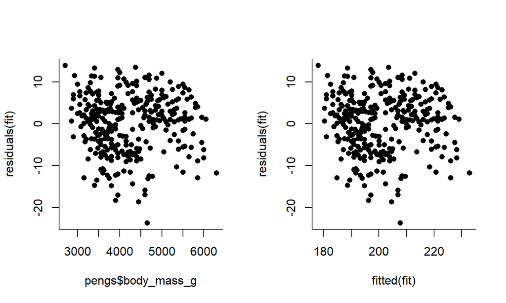

```r
par(mfrow=c(1,2), pch=16,bty="l")
plot(pengs$body_mass_g, residuals(fit))
plot(fitted(fit), residuals(fit))
```

Non ci sono forti segnali di varianza non costante, ma è presente una qualche struttura nei grafici.

R inoltre produce di default una serie di utili grafici basati sui residui quando si usa la funzione `plot` su un oggetto di classe `lm`:

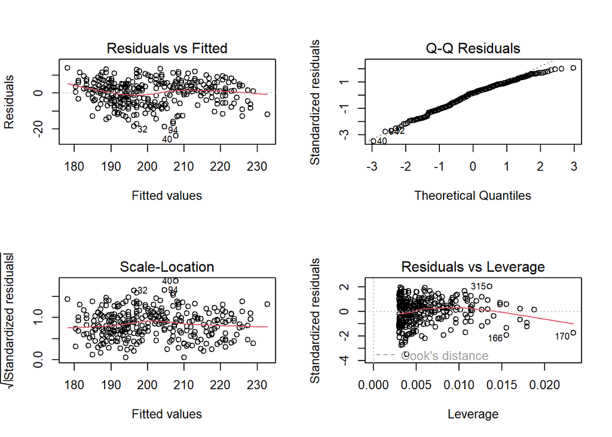

```r
par(mfrow=c(2,2))
plot(fit)
```

Vedremo più in dettaglio questi grafici nelle prossime lezioni.

Sebbene sia stato mostrato come il modello di regressione lineare sia relativamente robusto ad alcune deviazioni dal modello - la stima dei parametri si basa sulle assunzioni specificate: se queste assunzioni non sono riscontrabili nei dati si corre il rischio di fare un inferenza non affidabile. è sempre raccomandabile verificare che le assunzioni del modello siano soddisfatte prima di utilizzare un modello per fare predizioni e prendere decisioni.

# 4 Verifiche della teoria tramite simulazione

La simulazione è un approccio molto utile per indagare come si comportano i vari metodi di stima e per verificare in maniera empirica come si comportano gli stimatori. Il creare una procedura di simulazione dei dati per altro aiuta molto a capire in profondità quali sia il processo sotteso alla generazione dei dati che viene ipotizzato dal modello.

Valutiamo quindi alcune proprietà degli stimatori tramite la simulazione di dati le cui caratteristiche possiamo controllare, per esempio valutiamo la proprietà di non-distorsione e le formule derivate per la variabilità degli stimatori e come questa dipenda dalla variabilità del predittore (esempio a slide 105):

$$\mbox{se}(\hat{\beta}_1)=\frac{\sigma}{\sqrt{n
s^2_X}}
\quad \mbox{and} \quad
\mbox{se}(\hat{\beta}_0)=\sigma\sqrt{\frac{1}{n} +\frac{
\overline{x}^2}{n s^2_X}}$$

Il modello teorico:

$$Y=\beta_0 + \beta_1 X +
\varepsilon$$

$\varepsilon$ iid, omoschedastici a media 0, per esempio potremmo prendere $\varepsilon \sim Exp(1) - 1$.

Proviamo a vedere cosa succede quando prendiamo $X \sim U(-1,1)$ o $X \sim U(-3,3)$

```r
set.seed(324) # per riproducibilità
n = 100
x1 <- runif(n, -1, 1)
x2 <- runif(n, -3, 3)
compCoefs <- function(n, beta0 = 1, beta1 = 2, x1, x2){
  epsilon <- rexp(n, rate = 1) - 1
  y1 <- beta0 + beta1 * x1 + epsilon
  y2 <- beta0 + beta1 * x2 + epsilon
  c(coef(lm(y1 ~ x1)),  coef(lm(y2 ~ x2)))
}
outSum <- t(replicate(1000, compCoefs(n = n, x1 = x1, x2 = x2)))
```

In questo caso dovremmo avere $E[\hat{\beta_0}] = 1$ e $E[\hat{\beta_1}] = 2$ e

```r
# cfr slide 97
## std teorici quando X~unif(-1,1), cioè con varianza = 2^2/12 (e E[X] = 0)
# se(beta0)
sqrt(1/n + 0/(n*(4/12)))
```

```
## [1] 0.1
```

```r
# se(beta1)
sqrt(1/(n*(4/12)))
```

```
## [1] 0.1732051
```

```r
## std teorici quando X~unif(-3,3), cioè con varianza = 6^2/12 (e E[X] = 0)
# se(beta0)
sqrt(1/n + 0/(n*(36/12)))
```

```
## [1] 0.1
```

```r
# se(beta1)
sqrt(1/(n*(36/12)))
```

```
## [1] 0.05773503
```

Troviamo

```r
apply(outSum,2,mean)
```

```
## (Intercept)          x1 (Intercept)          x2
##   0.9994155   1.9955849   0.9993980   2.0001138
```

```r
# non distorsione
apply(outSum,2,sd)
```

```
## (Intercept)          x1 (Intercept)          x2
##  0.10435474  0.17970089  0.10433034  0.06057991
```

```r
# valori molto simili a quelli teorici
```

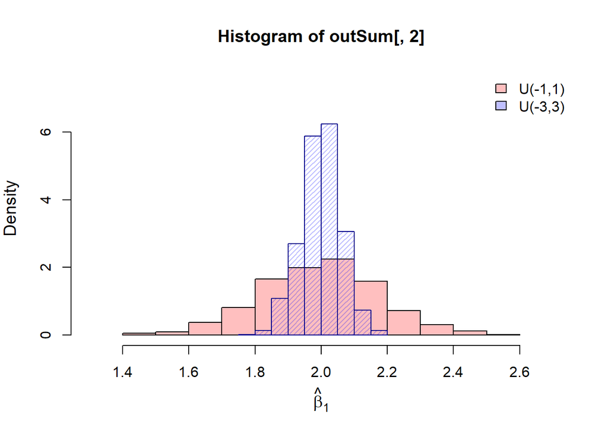

```r
hist(outSum[,2],col=rgb(1,0,0,1/4), freq=FALSE,xlab=expression(hat(beta)[1]),
     cex.lab=1.15,xlim=c(1.3,2.7),ylim=c(0,7.5))
hist(outSum[,4],col=rgb(0,0,1,1/4),add=TRUE,freq=FALSE, angle = 45, density = 25, border = "darkblue")
legend("topright",legend=c("U(-1,1)","U(-3,3)"),fill = c(rgb(1,0,0,1/4),rgb(0,0,1,1/4)), bty = "n")
```

Possiamo anche valutare l’incertezza della stima per la predizione dei valori di $m(x)$, che a slide 104 abbiamo detto essere

$Var[\hat{m}(x)|x,x_1, \ldots x_n] = \frac{\sigma^2}{n}\left(1 + \frac{(x-\overline{x})^2}{s^2_X}\right)$

```r
# valori teorici quando x1 = 0.1 o x1 = 1
sqrt((1/100) * (1+(0.1-0)^2/(4/12)) )
```

```
## [1] 0.1014889
```

```r
sqrt((1/100) * (1+(1-0)^2/(4/12)) )
```

```
## [1] 0.2
```

```r
# valori derivati dalle stime ripetute
sd(outSum[,1] + outSum[,2]*0.1)
```

```
## [1] 0.1059681
```

```r
sd(outSum[,1] + outSum[,2]*1)
```

```
## [1] 0.2081979
```

Controlliamo anche che la stima sia in media corretta (non distorta - unbiased)

```r
# valori teorici quando x1 = 0.1 o x1 = 1
1 + 2* 0.1; 1 + 2* 1
```

```
## [1] 1.2
```

```
## [1] 3
```

```r
# valori derivati dalle stime ripetute
mean(outSum[,1] + outSum[,2]*0.1)
```

```
## [1] 1.198974
```

```r
mean(outSum[,1] + outSum[,2]*1)
```

```
## [1] 2.995
```

Visivamente possiamo guardare come cambia la stima per $m(x)$ per diversi valori di x nelle diverse simulazioni:

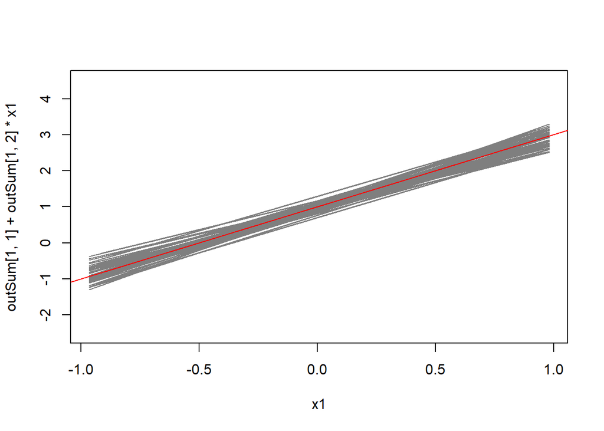

```r
plot(x1, outSum[1,1] + outSum[1,2]*x1, type = "l", ylim = c(-2.5,4.5), col = "grey50")
for(j in 2:50) lines(x1, outSum[j,1] + outSum[j,2]*x1, col = "grey50")
abline(1,2, col = "red", lwd = 1.3)
```

**Esercizio** Fino ad ora abbiamo preso $\epsilon \sim (Exp(\lambda)-\lambda)$ con $\lambda = 1$: cosa succede alla stima se cambiamo il parametro della distribuzione esponenziale?